# Sales Prediction Model Using NN

**Problem Refinement**: From the initial data files which contain data for around 3 years for a partiular store of a store chain, the data has been refined based on the number of products sold across one store for our analysis. In the refined data, user is asked to select a product for which prediction is required from a particular Chain and the quantities sold are summed up for that product across a particular store on a particular day. Further certain data points are added that may affect the sale, eg. day of a week, special days (Country Holidays) and Seasons (Summer, Winter, Autumn, Spring). To train the data model, previous day sale quantity of a particular product has also been added so that the sale pattern could be analyzed.

```python
import pandas as pd
import datetime as dt
import numpy as np
import holidays
import os
import logging
import sys
```

**User Inputs :** The model takes below inputs and trains itself at the runtime:

1. File path
2. Product Id
3. Start and End Timings of a day
4. Country of the store for incorporating the Holiday information.
5. Number of days from the last day in the input data for which the prediction is required.

```python
while True:
    try:
        file_path = str(input("Please Enter Data File Path"))
        df2_temp = pd.read_csv(filepath_or_buffer = file_path, sep = '|', header = None,  index_col=False, names=['Store_id', 'timestamp', 'Product_id','quantity','weight','coupon_no','dicount_qty','receipt_no','extended_price','discount_amount','sales_dollars','discount_dollars'])
    except FileNotFoundError:
        print("File Not Found.")
    except Exception as e:
        print("Error in reading")
        print (e)
    else:
        break
```

```
Please Enter Data File PathDesktop\Sample\sales2016\Sales2016-Store28.csv
```

```python
while True:
    try:
        file_path = str(input("Please Enter Data File Path"))
        df3_temp = pd.read_csv(filepath_or_buffer = file_path, sep = '|', header = None,  index_col=False, names=['Store_id', 'timestamp', 'Product_id','quantity','weight','coupon_no','dicount_qty','receipt_no','extended_price','discount_amount','sales_dollars','discount_dollars'])
    except FileNotFoundError:
        print("File Not Found.")
    except Exception as e:
        print("Error in reading")
        print (e)
    else:
        break
```

```
Please Enter Data File PathDesktop\Sample\sales2017\Sales2017-Store28.csv
```

```python
while True:
    try:
        file_path = str(input("Please Enter Data File Path"))
        df4_temp = pd.read_csv(filepath_or_buffer = file_path, sep = '|', header = None,  index_col=False, names=['Store_id', 'timestamp', 'Product_id','quantity','weight','coupon_no','dicount_qty','receipt_no','extended_price','discount_amount','sales_dollars','discount_dollars'])
    except FileNotFoundError:
        print("File Not Found.")
    except Exception as e:
        print("Error in reading")
        print (e)
    else:
        break
```

```
Please Enter Data File PathDesktop\Sample\sales2018-current\Sales2018-Current-Store28.csv
```

```python
final_temp_df = pd.concat([df2_temp, df3_temp, df4_temp], ignore_index=True, sort=False)
```

```python
df_data = final_temp_df.loc[final_temp_df['Product_id'] != 0]
```

```python
products = [7203695281,902,7203695431,7203695128, 104, 520, 839,800582501,2301200017 ]
while True:
    try:
        product = int(input("Please Enter a product_id"))
    except ValueError:
        print("Please provide a valid product_id")
    except:
        print("Please try again")
    else:
        if product not in products :
            print(f"Product Id not available in this store, Available Products:{products}")
        else:
            break
            clear_output()
            print(f"Analyzing for product {product}")
```

```
Please Enter a product_id7203695128
```

```python
df2_product = df_data.loc[df_data['Product_id'] == product]
```

```python
df2_product["timestamp"] = pd.to_datetime(df2_product["timestamp"])
#df2_product['yearwise'] = df2_product['timestamp'].dt.year
#df2_product['weeknum'] = df2_product['timestamp'].dt.week
df2_product['daywise'] = df2_product['timestamp'].dt.date
```

```python
timeformat = "%H:%M:%S"
while True:
    caminput1 = input("specify Start time in HH:MM:SS format: ")
    try:
        start_time = dt.datetime.strptime(caminput1, timeformat)
    except ValueError:
        print("Please enter correct time in HH:MM:SS format")
    else:

        break
```

```
specify Start time in HH:MM:SS format: 00:00:00
```

```python
while True:
    caminput2 = input("specify End time in HH:MM:SS format: ")
    try:
        end_time = dt.datetime.strptime(caminput2, timeformat)
    except ValueError:
        print("Please enter correct time in HH:MM:SS format")
    else:
        break
```

```
specify End time in HH:MM:SS format: 23:59:59
```

```python
index = pd.DatetimeIndex(df2_product['timestamp'])
df2_product_time = df2_product.iloc[index.indexer_between_time(start_time.time(),end_time.time())]
```

```python
df2_product_daywise = df2_product_time.groupby(["daywise", "Store_id","Product_id"]).agg({"quantity": "sum"}).reset_index()
```

```python
df2_product_daywise = df2_product_daywise.sort_values(by=['Store_id','daywise'])
```

```python
while True:
    try:
        pred_days = int(input("Please Enter the Number of days for which prediction is required"))
    except ValueError:
        print("Please provide a valid number of days")
    except:
        print("Please try again")
    else:
        break
```

```
Please Enter the Number of days for which prediction is required30
```

```python
df2_product_daywise['prev_day_qty'] = df2_product_daywise['quantity'].shift(1)
```

```python
df2_product_daywise = df2_product_daywise.groupby(["Store_id"], group_keys=False).apply(lambda x: x[1:])
```

```python
df2_product_daywise["day_of_week"] = pd.to_datetime(df2_product_daywise["daywise"], format="%Y-%m-%d").dt.dayofweek
df2_product_daywise["Seasons"] = pd.to_datetime(df2_product_daywise["daywise"], format="%Y-%m-%d").apply(lambda dt: (dt.month%12 + 3)//3)
```

```python
unq_years = pd.to_datetime(df2_product_daywise["daywise"], format="%Y-%m-%d").dt.year.unique()

while True:
    try:
        country = str(input("Please Enter Country of the Store (Use Title casing) or Country Abbr.\n For Eg: For United Kingdom use 'UnitedKingdom' or 'UK'."))
        ct_holidays = getattr(holidays,country)(years=unq_years)
    except AttributeError:
        print("Name Mismatch. Please Select from these Options:\nArgentina/AR\nAustralia/AU\nAustria/AT\nBelarus/BY\nBelgium/BE\nBrazil/BR\nBulgaria/BG\nCanada/CA\nColombia/CO\nCroatia/HR\nCzech/CZ\nDenmark/DK\nEngland\nEuropeanCentralBank/ECB,TAR\nFinland/FI\nFrance/FRA\nGermany/DE\nHungary/HU\nIndia/IND\nIreland/IE\nIsleOfMan\nItaly/IT\nJapan/JP\nLithuania/LT\nLuxembourg/LU\nMexico/MX\nNetherlands/NL\nNewZealand/NZ\nNorthern Ireland\nNorway/NO\nPolish/PL\nPortugal/PT\nPortugalExt/PTE\nRussia/RU\nScotland\nSlovenia/SI\nSlovakia/SK\nSouth Africa/ZA\nSpain/ES\nSweden/SE\nSwitzerland/CH\nUkraine/UA\nUnitedKingdom/UK\nUnitedStates/US\nWales\n")
    except ValueError:
        print("Enter a Valid Input")
    except:
        print("Please try again")
    else:
        break
```

```
Please Enter Country of the Store (Use Title casing) or Country Abbr.
 For Eg: For United Kingdom use 'UnitedKingdom' or 'UK'.US
```

```python
df2_product_daywise['Special_day'] = pd.to_datetime(df2_product_daywise["daywise"], format="%Y-%m-%d").isin(ct_holidays)

df2_product_daywise['Special_day'] = df2_product_daywise['Special_day'].apply(lambda x: 1 if x == True else x)
df2_product_daywise['Special_day'] = df2_product_daywise['Special_day'].apply(lambda x: 0 if x == False else x)
```

```python
df = df2_product_daywise.copy()
```

```python
#df
```

A **deep neural network (DNN)** is an artificial neural network (ANN) with multiple layers between the input and output layers. The DNN finds the correct mathematical manipulation to turn the input into the output, whether it be a linear relationship or a non-linear relationship. The network moves through the layers calculating the probability of each output.

A diagram of what one node might look like.

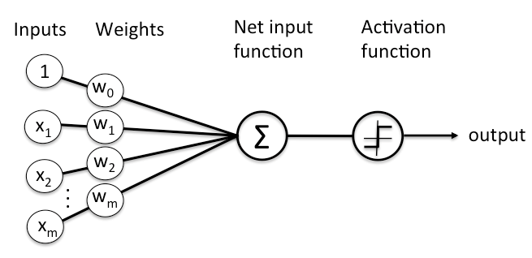

A node layer is a row of those neuron-like switches that turn on or off as the input is fed through the net. Each layer’s output is simultaneously the subsequent layer’s input, starting from an initial input layer receiving your data.

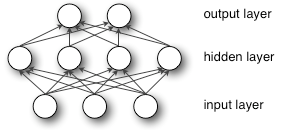

Pairing the model’s adjustable weights with input features is how we assign significance to those features with regard to how the neural network classifies and clusters input.

A collection of weights, whether they are in their start or end state, is also called a model, because it is an attempt to model data’s relationship to ground-truth labels, to grasp the data’s structure. Models normally start out bad and end up less bad, changing over time as the neural network updates its parameters.

Input enters the network. The coefficients, or weights, map that input to a set of guesses the network makes at the end.

**input * weight = guess**

Weighted input results in a guess about what that input is. The neural then takes its guess and compares it to a ground-truth about the data, effectively asking an expert “Did I get this right?”

**ground truth - guess = error**

The difference between the network’s guess and the ground truth is its error. The network measures that error, and walks the error back over its model, adjusting weights to the extent that they contributed to the error.

**error * weight's contribution to error = adjustment**

In fact, anyone who understands linear regression, one of first methods we learn in statistics, can understand how a neural net works. In its simplest form, linear regression is expressed as

**Y_hat = bX + a**

where Y_hat is the estimated output, X is the input, b is the slope and a is the intercept of a line on the vertical axis of a two-dimensional graph.

The next step is to imagine multiple linear regression, where you have many input variables producing an output variable. It’s typically expressed like this:

**Y_hat = b_1*X_1 + b_2*X_2 + b_3*X_3 + a**

Now, that form of multiple linear regression is happening at every node of a neural network. For each node of a single layer, input from each node of the previous layer is recombined with input from every other node. That is, the inputs are mixed in different proportions, according to their coefficients, which are different leading into each node of the subsequent layer. In this way, a net tests which combination of input is significant as it tries to reduce error.

Each output node produces two possible outcomes, the binary output values 0 or 1. The mechanism we use to convert continuous signals into binary output is called **logistic regression** . The name is unfortunate, since logistic regression is used for classification rather than regression in the linear sense that most people are familiar with. It calculates the probability that a set of inputs match the label.

For continuous inputs to be expressed as probabilities, they must output positive results, since there is no such thing as a negative probability. That’s why we see input as the exponent of e in the denominator – because exponents force our results to be greater than zero.

```python
class NeuralNetwork(object):
    def __init__(self, input_nodes, hidden_nodes, output_nodes, learning_rate):
        # Set number of nodes in input, hidden and output layers.
        self.input_nodes = input_nodes
        self.hidden_nodes = hidden_nodes
        self.output_nodes = output_nodes

        # Initialize weights
        self.weights_input_to_hidden = np.random.normal(0.0, self.input_nodes**-0.5,
                                       (self.input_nodes, self.hidden_nodes))

        self.weights_hidden_to_output = np.random.normal(0.0, self.hidden_nodes**-0.5,
                                       (self.hidden_nodes, self.output_nodes))
        self.lr = learning_rate

        #### TODO: Set self.activation_function to your implemented sigmoid function ####
        #
        # Note: in Python, you can define a function with a lambda expression,
        # as shown below.
        self.activation_function = lambda x : 1 / (1 + np.exp(-x))  # Replace 0 with your sigmoid calculation.

        ### If the lambda code above is not something you're familiar with,
        # You can uncomment out the following three lines and put your
        # implementation there instead.
        #
        #def sigmoid(x):
        #    return 0  # Replace 0 with your sigmoid calculation here
        #self.activation_function = sigmoid


    def train(self, features, targets):
        ''' Train the network on batch of features and targets.

            Arguments
            ---------

            features: 2D array, each row is one data record, each column is a feature
            targets: 1D array of target values

        '''
        n_records = features.shape[0]
        #print("In train")
        delta_weights_i_h = np.zeros(self.weights_input_to_hidden.shape)
        delta_weights_h_o = np.zeros(self.weights_hidden_to_output.shape)
        for X, y in zip(features, targets):

            final_outputs, hidden_outputs = self.forward_pass_train(X)  # Implement the forward pass function below
            # Implement the backproagation function below
            #print(final_outputs,y)
            delta_weights_i_h, delta_weights_h_o = self.backpropagation(final_outputs, hidden_outputs, X, y,
                                                                        delta_weights_i_h, delta_weights_h_o)
        #print(final_outputs)
        self.update_weights(delta_weights_i_h, delta_weights_h_o, n_records)


    def forward_pass_train(self, X):
        ''' Implement forward pass here

            Arguments
            ---------
            X: features batch

        '''
        #### Implement the forward pass here ####
        ### Forward pass ###
        # TODO: Hidden layer - Replace these values with your calculations.
        hidden_inputs = np.dot(X, self.weights_input_to_hidden) # signals into hidden layer
        hidden_outputs = self.activation_function(hidden_inputs) # signals from hidden layer

        # TODO: Output layer - Replace these values with your calculations.
        final_inputs = np.dot(hidden_outputs, self.weights_hidden_to_output) # signals into final output layer
        final_outputs = final_inputs # signals from final output layer

        return final_outputs, hidden_outputs

    def backpropagation(self, final_outputs, hidden_outputs, X, y, delta_weights_i_h, delta_weights_h_o):
        ''' Implement backpropagation

            Arguments
            ---------
            final_outputs: output from forward pass
            y: target (i.e. label) batch
            delta_weights_i_h: change in weights from input to hidden layers
            delta_weights_h_o: change in weights from hidden to output layers

        '''
        #### Implement the backward pass here ####
        ### Backward pass ###

        # TODO: Output error - Replace this value with your calculations.
        #print(y,final_outputs)
        error = y-final_outputs # Output layer error is the difference between desired target and actual output.

        # TODO: Calculate the hidden layer's contribution to the error
        hidden_error = np.dot(error,self.weights_hidden_to_output.T)

        # TODO: Backpropagated error terms - Replace these values with your calculations.
        output_error_term = error

        hidden_error_term = hidden_error*hidden_outputs*(1-hidden_outputs)

        # Weight step (input to hidden)
        delta_weights_i_h += hidden_error_term * X[:, None]
        # Weight step (hidden to output)
        delta_weights_h_o += output_error_term * hidden_outputs[:,None]
        return delta_weights_i_h, delta_weights_h_o

    def update_weights(self, delta_weights_i_h, delta_weights_h_o, n_records):
        ''' Update weights on gradient descent step

            Arguments
            ---------
            delta_weights_i_h: change in weights from input to hidden layers
            delta_weights_h_o: change in weights from hidden to output layers
            n_records: number of records

        '''
        self.weights_hidden_to_output += self.lr*delta_weights_h_o/n_records # update hidden-to-output weights with gradient descent step
        self.weights_input_to_hidden += self.lr*delta_weights_i_h/n_records # update input-to-hidden weights with gradient descent step

    def run(self, features):
        ''' Run a forward pass through the network with input features

            Arguments
            ---------
            features: 1D array of feature values
        '''

        #### Implement the forward pass here ####
        # TODO: Hidden layer - replace these values with the appropriate calculations.
        hidden_inputs = np.dot(features, self.weights_input_to_hidden) # signals into hidden layer
        hidden_outputs = self.activation_function(hidden_inputs) # signals from hidden layer

        # TODO: Output layer - Replace these values with the appropriate calculations.
        final_inputs = np.dot(hidden_outputs, self.weights_hidden_to_output) # signals into final output layer
        final_outputs = final_inputs # signals from final output layer

        return final_outputs
```

The refined file is used as an input and 3 days rolling mean and 3 days standard deviation are added as parameters. The data points are scaled and are fed to our model to predict the sale output with greater accuracy.

```python
#df=pd.read_excel("Desktop\\asda_1718_6200129_daywise1.xlsx")
#df=pd.get_dummies(df,columns=['day_of_week','Special_day','Seasons','Store_id'], prefix=['day_of_week','Special_day','Seasons','Store_id'])
df['Rolling_Mean']=df['prev_day_qty'].rolling(3).mean()
df['3 Day STD'] = df['prev_day_qty'].rolling(window=3).std()

#Group Records by Store_id and remove first 2 records to emiminate NaN values for Rolling means and STD Deviation
df = df.groupby(["Store_id"], group_keys=False).apply(lambda x: x[2:])
df["Actual_Store_Id"]=df['Store_id']
#df.groupby(["daywise"])
df=df.sort_values(by=['daywise'], ascending=[True])
df=pd.get_dummies(df,columns=['day_of_week','Special_day','Seasons','Store_id'], prefix=['day_of_week','Special_day','Seasons','Store_id'])
#df
```

```python
pred_day_df = df[-pred_days-2:].copy()
training_df= df[:-pred_days].copy()
df=training_df.copy()
```

```python
df.dropna(inplace=True)
quant_features=['quantity','prev_day_qty','Rolling_Mean','3 Day STD']
scaled_features = {}
for each in quant_features:
    mean, std = df[each].mean(), df[each].std()
    scaled_features[each] = [mean, std]
    df.loc[:, each] = (df[each] - mean)/std
#df=df.drop(['Product_id','product_name','daywise'],1)
```

```python
rows, columns = df.shape
```

```python
target_fields=['quantity']
#df1=df
features, targets = df.drop(columns=['daywise','Product_id','Actual_Store_Id', 'quantity'], axis=1), df[target_fields]
#test_features, test_targets = features[-pred_days:], targets[-pred_days:]
```

The entire data frame is divided into 2 parts, (training features & training targets) and (validation features & validation targets). As the name explains the first data set is passed as a training parameter and the second as validation paramater to the model. Based on which the probable output is predicted, which is quantity in our case.

```python
train = round((rows)*0.8)
```

```python
#df1=df
#features, targets = df.drop(columns=['daywise','Product_id','Actual_Store_Id', 'pred_day_qty'], axis=1), df[target_fields]
train_features, train_targets = features[0:train], targets[0:train]
```

```python
#test  = train+1+last_half
train_features.shape
```

```
(468, 17)
```

```python
val_features, val_targets = features[train+1:(rows)], targets[train+1:(rows)]
```

The function below calculates the Mean Squared Error. In statistics, the mean squared error (MSE) of an estimator measures the average of the squares of the errors — that is, the average squared difference between the estimated values and what is estimated. MSE is a risk function, corresponding to the expected value of the squared error loss.

```python
def MSE(y,Y):
    return np.mean((y-Y)**2)
```

The learning rate and the iterations are two very important parameters that control how effectively the backpropagation algorithm trains the neural network. The learning rate is a positive constant that controls the rate at which the new weight factors are adjusted based on the calculated gradient-descent correction term. This difference in the number of training iterations can become even more pronounced and significant in more complex networks.

These inputs and data points are passed to the model; training and validation losses are calculated based on the output probability. Training and Validation losses tending to 0 depicts a good model

```python
#########################################################
# Set your hyperparameters here
##########################################################
iterations = 4000
learning_rate = 0.01
hidden_nodes = 35
output_nodes = 1

print("strt prg",iterations, learning_rate, hidden_nodes, output_nodes)


N_i = train_features.shape[1]
network = NeuralNetwork(N_i, hidden_nodes, output_nodes, learning_rate)

losses = {'train':[], 'validation':[]}
for ii in range(iterations):
    # Go through a random batch of 128 records from the training data set
    batch = np.random.choice(train_features.index, size=128)
    X, y = train_features.ix[batch].values, train_targets.ix[batch]['quantity']
    #print(X)
    network.train(X, y)

    # Printing out the training progress
    train_loss = MSE(network.run(train_features).T, train_targets['quantity'].values)
    val_loss = MSE(network.run(val_features).T, val_targets['quantity'].values)
    sys.stdout.write("\rProgress: {:2.1f}".format(100 * ii/float(iterations))  + "% ... Training loss: " + str(train_loss)[:5]                      + " ... Validation loss: " + str(val_loss)[:5])
    sys.stdout.flush()

    losses['train'].append(train_loss)
    losses['validation'].append(val_loss)
```

```
strt prg 4000 0.01 35 1
Progress: 0.1% ... Training loss: 1.173 ... Validation loss: 0.676
```

```
Progress: 100.0% ... Training loss: 0.349 ... Validation loss: 0.863
```

```python
pred_day_df=pred_day_df.reset_index(drop=True)
```

```python
pred_day_df1=pred_day_df.copy()
```

The Model post training is fed with the a dataset that has been splitted from the initial dataaset based on the user input for 'Number of days from the last day in the input data for which the prediction is required'. And based on the input given, model now predicts sale qunatity.

```python
count=0
predit = []
act = []

while count < pred_days:
    testset_df=pred_day_df.ix[count:count+2].copy()
    tempmean=testset_df['prev_day_qty'].rolling(3).mean()
    tempstd=testset_df['prev_day_qty'].rolling(window=3).std()
    #print(tempmean.iloc[-1],tempstd.iloc[-1])
    testset_df['Rolling_Mean'].ix[count+2]=tempmean.iloc[-1]
    testset_df['3 Day STD'].ix[count+2]=tempstd.iloc[-1]
    #display(testset_df)

    #testset_df = testset_df.apply(lambda x: x[2:])
    #testset_df=testset_df[count+2:]

    pred_quant_features=['prev_day_qty','Rolling_Mean','3 Day STD','quantity']
    pred_scaled_features = {}
    for each in pred_quant_features:
        #print(testset_df[each].mean(), testset_df[each].std())
        mean, std = testset_df[each].mean(), testset_df[each].std()
        pred_scaled_features[each] = [mean, std]
        testset_df.loc[:, each] = (testset_df[each] - mean)/std
    pred_target_fields=['quantity']
    #df1=df
    testset_df = testset_df.apply(lambda x: x[2:])
    pred_features, pred_targets = testset_df.drop(columns=['daywise','Product_id','quantity','Actual_Store_Id'], axis=1), testset_df[pred_target_fields]
    #display(pred_features)
    mean, std = pred_scaled_features['quantity']
    predictions = network.run(pred_features)[0][0]*std + mean
    #display("output",round(predictions),testset_df['quantity'].ix[count+2]*std + mean)

    predit.append(round(predictions))
    act.append(testset_df['quantity'].ix[count+2]*std + mean)

    pred_day_df['prev_day_qty'].ix[count+3]=round(predictions)
    pred_day_df['Rolling_Mean'].ix[count+2]=tempmean.iloc[-1]
    pred_day_df['3 Day STD'].ix[count+2]=tempstd.iloc[-1]
    #print(pred_day_df)

    count+=1
```

[output not shown]